# Plotting Ocean Data With R

# Damariscotta River cruise data

For this tutorial we’re going to use some water column data from the Damariscotta River. The data spans 3 years and is at four locations along the river.

The data file is called `DamariscottaRiverData.csv` and is [in the data folder in the GitHub repository](https://github.com/cathmmitchell/plottingOceanDataWithR). If you haven’t already, please download the file and save it in your working directory. You can download the file by:

1. Click on the file name
2. Either select `View raw` (center of screen) or the `Download` button (to the right) - a new tab in your browser should open that shows the contents of the file
3. Right click anywhere on the window with the file contents
4. Select `Save page as`
5. Save the file into your working directory.

## Initialize session

First, we’ll load the `tidyverse` library:

```r
library(tidyverse)
```

## Importing the data

Let’s read the data into a data frame:

```r
fieldData <- read_csv('data/DamariscottaRiverData.csv')
```

What does this data look like?

```r
head(fieldData)
```

| date | station | depth_m | year | month | day | temperature_degC | salinity_psu | density_kg_m3 | PAR | fluorescence_mg_m3 | oxygenConc_umol_kg | oxygenSaturation_percent | latitude |
| --- | --- | --- | --- | --- | --- | --- | --- | --- | --- | --- | --- | --- | --- |
| 20160908 | 1 | 1 | 2016 | 9 | 8 | 17.82298 | 31.99910 | 23.01779 | 297.25714 | 4.307989 | 190.0219 | 79.34502 | 43.903 |
| 20160908 | 1 | 2 | 2016 | 9 | 8 | 17.42830 | 32.02599 | 23.13255 | 153.00000 | 4.603390 | 130.8483 | 54.23103 | 43.903 |
| 20160908 | 1 | 3 | 2016 | 9 | 8 | 17.37619 | 32.02510 | 23.14422 | 84.05556 | 4.537333 | 135.7394 | 56.19718 | 43.903 |
| 20160908 | 1 | 4 | 2016 | 9 | 8 | 17.35450 | 32.02631 | 23.15030 | 48.56250 | 4.523987 | 122.4051 | 50.65716 | 43.903 |
| 20160908 | 1 | 5 | 2016 | 9 | 8 | 17.30706 | 32.03236 | 23.16615 | 29.40000 | 4.924437 | 120.9471 | 50.01040 | 43.903 |
| 20160908 | 1 | 6 | 2016 | 9 | 8 | 17.22665 | 32.03581 | 23.18777 | 17.58750 | 4.728262 | 120.8665 | 49.90176 | 43.903 |

## Challenge A

1.a. Create a scatter plot of ‘fluorescence_mg_m3’ (x-axis) by ‘temperature_degC’ (y-axis) and color the points by ‘station’.

1.b. Do the same as 1.a. but convert the station values to factors. What’s the difference between the two plots?

2. Create boxplots looking at the distribution of temperature_degC by (tip: change the station values to factors).
3. Plot temperature by depth for samples for the cruise from September 8th 2016, coloring the points by station (tip: filter the data frame on the `date` column).

Challenge solutions are in a separate file available on the GitHub repository [`plottingOceanDataWithR-challengeSolutions.md`](https://github.com/cathmmitchell/plottingOceanDataWithR/blob/main/challengeSolutions.md)

# Some common customizations of `ggplot` figures

## `scale_y_reverse()`

For the last plot in Challenge A, we ended up with a plot that had the surface (0 m depth) at the bottom of the y-axis, and the bottom of the river at the top of the y-axis. Usually, we’d plot this the other way around - we’d flip the y-axis, or plot it in reverse.

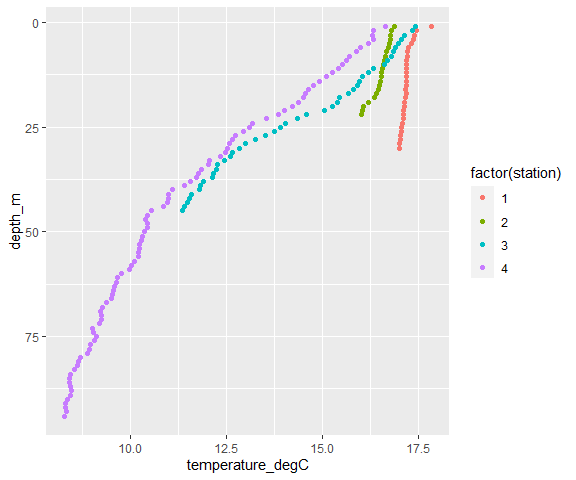

```r
datasubset <- fieldData %>% filter(date==20160908)

ggplot(data = datasubset, mapping = aes(x = temperature_degC, y = depth_m)) +
  geom_point(aes(color=factor(station))) +
  scale_y_reverse()
```

## `scale_y_log()`

In Challenge A #1 we plotted chlorophyll fluorescence against temperature. But the majority of the fluorescence data was at the lower end of the scale. In this case, it could be more useful to plot the fluorescence data on a log scale.

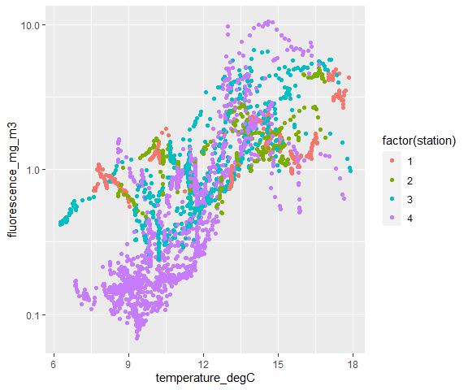

```r
ggplot(data = fieldData, mapping = aes(x = temperature_degC, y = fluorescence_mg_m3)) +
  geom_point(aes(color=factor(station))) +
  scale_y_log10()
```

## `labs()`

To modify plot legend label or title, use the `labs()` function. The `title` argument is used to specify a title for the figure. Depending on the type of plot, the legend label argument can vary. In the below, it’s the `color` argument of the `geom_point` that is controlling the legend entries, so we specify the legend label with the `color` argument.

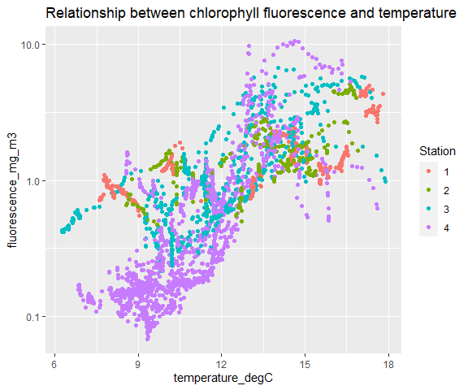

```r
ggplot(data = fieldData, mapping = aes(x = temperature_degC, y = fluorescence_mg_m3)) +
  geom_point(aes(color=factor(station))) +
  scale_y_log10() +
  labs(title = 'Relationship between chlorophyll fluorescence and temperature', color='Station')
```

# Visualizing relationships between multiple variables

In our initial exploration of the data, we’ve looked at how to plot some variables under some limited conditions e.g. profiles for one cruise, or relationships between a couple of variables for all cruises. We could have used Excel to do this plotting. But what about if we want to visualize our data in a different way that represented the time and space components of field data or if we wanted a more complicated subset of our data? That’s where R comes in really handy.

What we’re going to work towards here is plotting oceanographic data in similar way to [Ocean Data View](https://odv.awi.de/). By the end of the tutorial, we’ll have created:

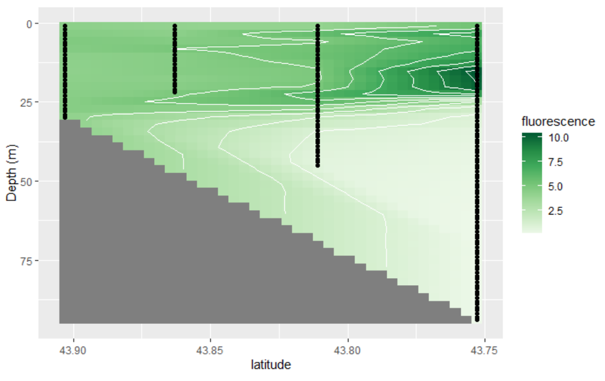

And we’ll have learned how to recreate the above figure under different requirements e.g. for a different variable, or different cruise.

But, it’s worth pointing out here that all the methods we’ll be using can be used on any type of data - and we’ll see some examples as we go through the tutorial.

## Contour and Bubble Plots

Let’s start by considering surface chlorophyll fluorescence at each station over the 2016 sampling season. Surface can be defined in multiple ways and the exact choices you make will depend on your data and your situation. Here, we are going to say surface chlorophyll fluorescence is the average value over the top 2 m.

We are going to create a couple of different figures that show surface chlorophyll fluorescence with date along the x-axis and station along the y-axis. Before creating the figures, we need to do some data manipulation to wrangle our data into a new data frame that contains 3 columns: date, station and surface chlorophyll fluorescence.

**Another example:** Say you’ve got three cultures that you’re testing four different treatments on. For each culture/treatment combination, you’re measuring cell counts at a series of time points. What you’d like to visualize/plot is the average cell counts over the first two time points for each culture and treatment.

How do the variables in these examples compare?

| Field Data | Lab Experiment |
| --- | --- |
| station | treatment |
| date | culture |
| depth | time point |

## Data Manipulation

### Dates

One of the variables we want to plot is date. We currently have date stored as a number in the format yyyymmdd, and in separate year, month and day columns. If we used the yyyymmdd data for plotting date, our dates would be spaced out incorrectly because R recognises this as a number. Let’s look the dates we have samples from:

```r
unique(fieldData$date)
```

```
 [1] 20160908 20160920 20161004 20161019 20161101 20170602 20170912 20170921 20171005 20171109 20171129 20180906 20180919 20180927 20181018 20181030
[17] 20181115
```

The second date is September 20th and the third is October 4th - a gap of 14 days. But R sees that as a gap of 84 (20161004-20160920), hence the spacing along the given axis would be incorrect.

What we need to do is format our dates in a way R recognises them as dates. Let’s use the `ymd` function from yesterday to convert the dates, and the `mutate` function to add the reformatted dates to our data frame.

```r
library(lubridate)
fieldDatanew <- mutate(fieldData, rdate = ymd(date))
```

There’s some more details about [formatting dates](https://github.com/cathmmitchell/plottingOceanDataWithR/wiki/Formatting-dates) on the GitHub Wiki page.

Our data frame contains data from 2016 - 2018, so we first need to `filter` the data frame based on year (select rows based on a specific criterion):

```r
data2016 <- fieldDatanew %>% filter(year == 2016)

#checking our data frame
summary(data2016)
```

```
      date             station         depth_m            year          month             day        temperature_degC  salinity_psu   density_kg_m3
 Min.   :20160908   Min.   :1.000   Min.   :  1.00   Min.   :2016   Min.   : 9.000   Min.   : 1.00   Min.   : 8.281   Min.   :31.69   Min.   :23.02
 1st Qu.:20160920   1st Qu.:2.000   1st Qu.: 13.00   1st Qu.:2016   1st Qu.: 9.000   1st Qu.: 4.00   1st Qu.:11.309   1st Qu.:32.34   1st Qu.:24.21
 Median :20161004   Median :3.500   Median : 28.00   Median :2016   Median :10.000   Median : 8.00   Median :12.715   Median :32.67   Median :24.69
 Mean   :20160991   Mean   :3.067   Mean   : 35.16   Mean   :2016   Mean   : 9.809   Mean   :10.43   Mean   :12.661   Mean   :32.62   Mean   :24.60
 3rd Qu.:20161019   3rd Qu.:4.000   3rd Qu.: 51.00   3rd Qu.:2016   3rd Qu.:10.000   3rd Qu.:19.00   3rd Qu.:13.813   3rd Qu.:32.88   3rd Qu.:25.12
 Max.   :20161101   Max.   :4.000   Max.   :105.00   Max.   :2016   Max.   :11.000   Max.   :20.00   Max.   :17.823   Max.   :33.25   Max.   :25.58
      PAR            fluorescence_mg_m3 oxygenConc_umol_kg oxygenSaturation_percent    latitude         rdate
 Min.   :   0.0001   Min.   : 0.08692   Min.   : 86.03     Min.   : 31.05           Min.   :43.75   Min.   :2016-09-08
 1st Qu.:   0.0001   1st Qu.: 0.60206   1st Qu.:106.90     1st Qu.: 39.37           1st Qu.:43.75   1st Qu.:2016-09-20
 Median :   0.4183   Median : 1.05324   Median :118.59     Median : 45.12           Median :43.78   Median :2016-10-04
 Mean   :  54.4916   Mean   : 1.56151   Mean   :126.07     Mean   : 47.97           Mean   :43.80   Mean   :2016-10-04
 3rd Qu.:  15.4295   3rd Qu.: 1.55218   3rd Qu.:138.88     3rd Qu.: 53.03           3rd Qu.:43.86   3rd Qu.:2016-10-19
 Max.   :1498.8235   Max.   :10.47805   Max.   :256.47     Max.   :103.05           Max.   :43.90   Max.   :2016-11-01
```

### Selecting and summarizing data

Learning how to code isn’t just about learning commands and syntax - it’s also about learning how to break down your analysis into steps that the computer can handle. Recall - here, we are going to say surface chlorophyll fluorescence is the average value over the top 2 m. What that means is for every cruise and station, we need to calculate the average chlorophyll fluorescence in the top 2 m.

## Challenge B

What are the steps we need to take to manipulate our data into a data frame with three columns: cruise, station and fluorescence averaged over the top 2 m? Describe the step and say the associated `dplyr` data frame manipulation functions you would use to do it.

### Back to selecting and summarizing the data

```r
chldata2016 <- data2016 %>% filter(depth_m < 2) %>% group_by(station,rdate) %>% summarize(surf_chl = mean(fluorescence_mg_m3))
head(chldata2016)
```

| station | rdate | surf_chl |
| --- | --- | --- |
| 1 | 2016-09-08 | 4.307989 |
| 1 | 2016-09-20 | 1.179140 |
| 1 | 2016-10-04 | 1.326641 |
| 1 | 2016-10-19 | 0.907080 |
| 1 | 2016-11-01 | 1.047285 |
| 2 | 2016-09-08 | 4.055563 |

We’ve manipulated our data into the form we need to now plot it. *However* in the process, we made two extra data frames that we are not going to use anymore: `data2016` and `fieldDatanew`. At each step of our manipulating, we needed to try and keep track of which data frame to use where. With only two it’s maybe OK to keep on top of, but if there are a lot more steps, you can sometimes get lost in sea of data frames. Pipes can really help keep your environment free of unnecessary objects.

In our case, we could have actually used pipes to do all the manipulations in one command. Note that we can combine the two calls to `filter` into one:

```r
chldata2016 <- fieldData %>% mutate(rdate = ymd(date)) %>% filter(year == 2016, depth_m < 2) %>% group_by(station,rdate) %>% summarize(surf_chl = mean(fluorescence_mg_m3))
```

## Visualizing data using a contour plot

We can visualize this type of data with a contour plot (using `geom_contour_filled()`). In this case, our argument to the `labs()` function for the legend (color bar) is going to be `fill`.

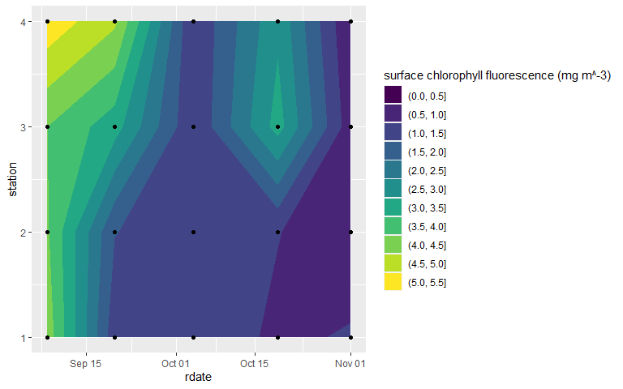

```r
ggplot(chldata2016,aes(x=rdate,y=station)) +
  geom_contour_filled(aes(z=surf_chl)) +
  geom_point() +
  labs(fill='surface chlorophyll fluorescence (mg m^-3)')
```

We can reformat the x-axis dates if we wished - see details in the [Formatting Dates wiki](https://github.com/cathmmitchell/plottingOceanDataWithR/wiki/Formatting-dates)

Here, the dots (from `geom_point`) show where the measurements were made, and the contours filled in the gaps. This helps us to visualize the time and space changes in chlorophyll fluorescence.

If we think about our lab experiment example, what our figure would show is treatment on the y-axis, culture on the x-axis, and cell counts as the contours. In that case - does it make sense to have the cell counts fill the gaps between the treatment and culture? No - the treatments and cultures are separate from each other. They are not connected in this temporal or spatial way. So while the *data manipulation* was the same for each data set, the *data visualization* isn’t.

## Visualizing data using a bubble plot

We are going to plot a scatter plot, where the size of each point represents the chlorophyll fluorescence. In this case, our argument to the `labs()` function for the legend is going to be `size`.

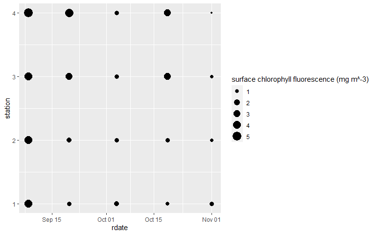

```r
ggplot(chldata2016,aes(x=rdate,y=station)) +
  geom_point(aes(size=surf_chl)) +
  labs(size='surface chlorophyll fluorescence (mg m^-3)')
```

# Interpolating and visualizing data

The approach in previous section works well when your data are consistent in terms of the variables you want to compare. For the data we plotted above, there were five different cruises, and on each cruise, data was collected at the same four locations. We had data for every cruise and station. If we’d been missing data at one of the stations on one of the cruises, we’d just have a blank part on the plots we made. But what if we were missing a lot of data - would the above approach still be a good way to visualize our data?

To dig into this a bit further, let’s consider how chlorophyll fluorescence varies by depth at each station *for one cruise*.

We need to do a bit of data manipulation again to create a data frame we’ll use for plotting. In this case, we’re going to have station on the x-axis and depth on the y-axis, and we’ll consider the cruise that took place on September 8th 2016.

```r
cruiseData <- filter(fieldData, date==20160908)
```

We now have a data frame that includes columns for depth, station and chlorophyll fluorescence for just one cruise - so let’s use the same approach as before to create a contour plot:

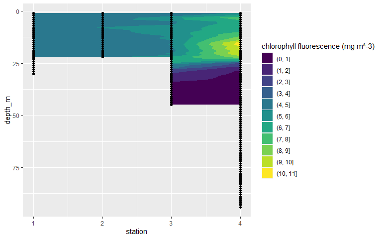

```r
ggplot(cruiseData,aes(x=station,y=depth_m)) +
  geom_contour_filled(aes(z=fluorescence_mg_m3)) +
  geom_point() +
  labs(fill='chlorophyll fluorescence (mg m^-3)') +
  scale_y_reverse() #flip y-axis
```

This looks good, but what this plotting function doesn’t do is interpolate data between missing data points. We know we have data at station 4 below 50 m that isn’t represented in this plot. Can we use a different function to show those data too? Yes - `geom_tile()`.

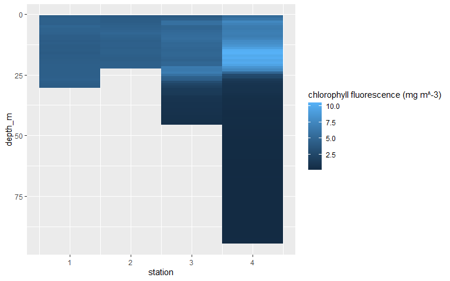

```r
ggplot(cruiseData,aes(x=station,y=depth_m)) +
  geom_tile(aes(fill=fluorescence_mg_m3)) +
  labs(fill='chlorophyll fluorescence (mg m^-3)') +
  scale_y_reverse()
```

Let’s go back to the lab experiment example: could it be plotted in this way?

Yes - depth could represent time points, and station could represent treatment.

## Challenge C

1. Create a `geom_tile` plot for temperature_degC from the cruise that took place on Sept 12th 2017.
2. Are there any examples from your own data that you could plot in this way?

## Interpolation

With our field data one axis has been station number i.e. it is a given location. We might want to space out the data on the x-axis based on those locations, rather than station number, so we can visualize our data with a representative separation between the data points. For this data set, the stations are on a similar longitude, so looking at latitude will give a good representation of the separation between the stations. For cruise or sampling tracks where both latitude and longitude are variable, this could be distance along the cruise path or field transect.

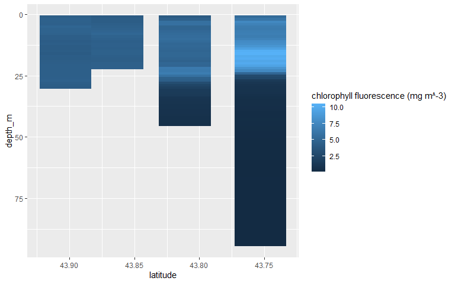

```r
ggplot(cruiseData,aes(x=latitude,y=depth_m)) +
  geom_tile(aes(fill=fluorescence_mg_m3)) +
  labs(fill='chlorophyll fluorescence (mg m^-3)') +
  scale_y_reverse() +
  scale_x_reverse() # flipping so station 1 is on the left
```

What we end up with is this plot where we have gaps between each station measurement because our sampling stations are not equally spaced in terms of latitude. What we can do is estimate what the chlorophyll fluorescence would be in between where we have our samples i.e. we can interpolate our data.

We are going to do the bilinear interpolation on our data, which means we are going to estimate chlorophyll fluorescence values over regularly spaced latitude and depth values. This is something that’s maybe more common when working with geospatial data. But in our lab experiment case, maybe we’d be interested in interpolating our cell counts between our different time points.

We’re going to use a handy function from the `akima` package to do all the hard work for us:

```r
library(akima)
#interpolate our data:
interpReference <- interp(cruiseData$latitude, cruiseData$depth_m, cruiseData$fluorescence_mg_m3)
```

What does `interpReference` look like? It is a list with 3 items:

1. `x`, which is a list of 40, regularly spaced latitudes
2. `y`, which is a list of 40, regularly spaced depths
3. `z`, which is a 40 x 40 grid (or **matrix**), where each **element** (number in the grid) corresponds to one of the depth (columns) and latitude (rows) values. For example,
   1. the `z` value in the first row and first column corresponds to the first latitude and depth values
   2. the `z` value in the first row and second column corresponds to the first latitude, and second depth value
   3. the `z` value in the second row and first column corresponds to the second latitude, and first depth value

What we now need to do is get our data into a data frame format for `ggplot`. One way to do this is use the `expand.grid` function to create a data frame from all combinations of the latitude and depth vectors. Then flatten the interpolated data matrix into a vector and add it as a column in the data frame.

```r
# making data frame from all combinations of latitude and depth
CruiseDataInterp <- expand.grid(latitude=interpReference$x,
                                depth = interpReference$y) %>%
  mutate(fluorescence = as.vector(interpReference$z))
```

**Note: Something to be aware of with the above step is if the matrix is flattened row-wise or column-wise. To make sure the flattened matrix elements align with the correct latitude and depth pair, you might need to transpose your matrix first (flip it along the diagonal) `t(interpReference$z)`**

Now we have our data frame - can we plot our data as before?

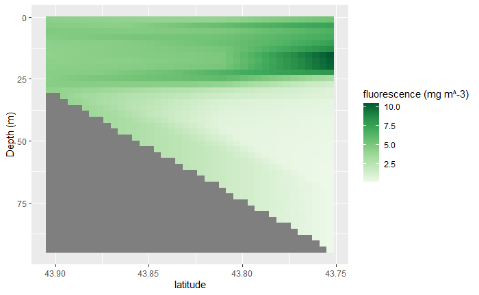

```r
ggplot(CruiseDataInterp, aes(x=latitude, y=depth)) +
  geom_tile(aes(fill = fluorescence)) +
  scale_y_reverse() +
  scale_x_reverse() + #so station1 is on the left and station4 is on the right
  labs(y="Depth (m)", fill="fluorescence (mg m^-3)") +
  scale_fill_distiller(palette="Greens",direction=1)
```

We can include the sample locations and contour lines to make it clear where the interpolation is happening:

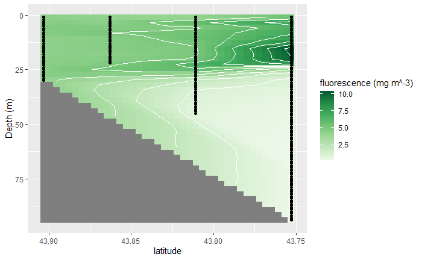

```r
ggplot(CruiseDataInterp, aes(x=latitude, y=depth)) +
  geom_tile(aes(fill = fluorescence)) +
  geom_contour(aes(z = fluorescence),color="white") +
  geom_point(data = cruiseData, aes(x=latitude, y=depth_m),color="black") + #adding in the measurement locations
  scale_y_reverse() +
  scale_x_reverse() + #so station1 is on the left and station4 is on the right
  labs(y="Depth (m)", fill="fluorescence (mg m^-3)") +
  scale_fill_distiller(palette="Greens",direction=1)
```

**Note: In this case (the Damariscotta River) we interpolated below the measured depths. But those interpolations don’t make sense here because the profiles are full water column i.e. depth was limited by bathymetery.**

## Challenge D

Create a plot like the above that shows temperature interpolated by depth and latitude for the cruise that took place on Sept 12th 2017.

# Functions and for loops for creating multiple versions of figures

## Writing Functions

Functions are blocks of code which when called, perform a specific task. Usually you give them an input and they give you an output. We’ve used lots of different R functions e.g. `ggplot`, `mutate`, etc. We can write our own functions for our own specific tasks. If you find yourself copying and pasting blocks of code and changing just a couple small parts, that’s often a good time to think about writing a function (or a for loop - more later!)

#### Example: write a function which adds two numbers

```r
addition <- function(a,b){
  return(a+b)
}
```

Let’s try using our function:

```r
addition(9,3)
```

```
[1] 12
```

### Function for creating a figure

The last figure we created was for one variable, for one cruise. What if we want to look at a different variable? Or a different cruise? It would be nice to have a function to regenerate a plot quickly.

We’re going to write a function that creates the above figure. It’s going to have two parts: first, we’ll deal with the data manipulation, and second, we’ll deal with the plotting.

#### Data manipulation revisit

As a reminder, here’s the steps we took earlier to do the data manipulation:

1. Filtered the original data frame based on cruise date
2. Interpolated the relevant variable based on depth and latitude
3. Reshaped the data back into a data frame

#### Writing the function

The following code will all be a copy from what we did earlier, but a few of the object names will be generalized e.g. we’ll use `dataframe` rather than `fieldData`, call the column we want to plot `variable` rather than “hard coding” its name “fluorescence_mg_m3” and the date `cruiseDate` (as well as renaming a couple of the intermediate objects created along the way).

We need to think about what the inputs of our function are going to be - these are the variables or objects we want to change e.g. variable or cruise date. We also need to think about our output: a plot.

Good practice for when you write a function is to include a short description (as a comment) at the start of the function that describes what it does. It can be useful to list details of the input and output objects - for yourself, but also for anyone you might share your code with.

```r
cruiseInterpolationPlot <- function(dataframe, variable, cruiseDate, colorlabel){
  # return a heatmap style plot for a variable interpolated over latitude and
  # depth
  # Inputs: dataframe = raw data frame of the DamariscottaRiverData
  #         variable = data frame column name (as a string) of the variable to
  #                    interpolate
  #         cruiseData = numeric value of date in yyyymmdd (to compare with the
  #                      dataframe$date column)
  #         colorlabel = label for the color bar (as a string)

  cruiseData <- dataframe %>% filter(date == cruiseDate)

  #interpolate our data:
  interpReference <- interp(cruiseData$latitude, cruiseData$depth_m, cruiseData[[variable]])

  newdf <- expand.grid(latitude=interpReference$x,
                                depth_m = interpReference$y) %>%
  mutate(varname = as.vector(interpReference$z))

  p <- ggplot(newdf, aes(x=latitude, y=depth_m)) +
    geom_tile(aes(fill = varname)) +
    geom_contour(aes(z = varname),color="white") +
    geom_point(data = cruiseData, aes(x=latitude, y=depth_m),color="black") + #adding in the measurement locations
    scale_y_reverse() +
    scale_x_reverse() + #so station1 is on the left and station4 is on the right
    labs(y="Depth (m)", fill=colorlabel, title = cruiseDate) +
    scale_fill_distiller(palette="Greens",direction=1)

  return(p)

}
```

Now we can try out our function by trying to make the same plot as before:

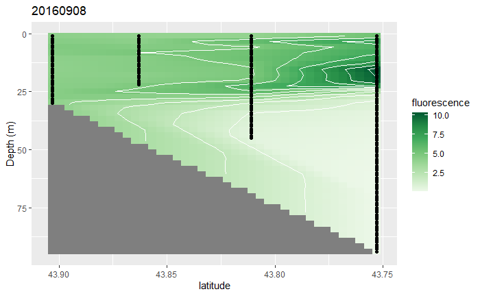

```r
cruiseInterpolationPlot(fieldData,'fluorescence_mg_m3',20160908,'fluorescence')
```

## Challenge E

Create a plot like the above that shows fluorescence interpolated by depth and latitude for every cruise in 2016 (one plot per cruise). To get a list of all the dates of cruises in 2016 do `unique(data2016$date)` and look at the object printed to the console.

## For Loops

For loops are a way we can repeat a specific task a set number of times. For Challenge E, we created plots for every cruise in 2016. To do that, we wrote out the call to our `cruiseInterpolationPlot` function a number of times, with a different date in each call to the function. We needed to know what the exact dates were to enter into our plotting function. We could have used a for loop to keep track of all of those parts for us.

### For loop example

#### Example: print the statement “hello” four times

```r
for (ii in 1:4) {
  print("hello")
}
```

```
[1] "hello"
[1] "hello"
[1] "hello"
[1] "hello"
```

Can we also print which loop iteration we are on (e.g. the first, second, etc)?

```r
for (ii in 1:4) {
  print(paste(ii,"hello"))
}
```

```
[1] "1 hello"
[1] "2 hello"
[1] "3 hello"
[1] "4 hello"
```

Can we build a list over a for loop? For example, let’s build a list that contains the iteration number multiplied by 10.

```r
mylst <- vector("list",length=4)
for (ii in 1:4) {
  mylst[[ii]] = ii*10
}
```

We have our function for plotting the data - let’s try and do Challenge E again, but calling our function in a for loop.

Let’s think about what we want to loop over - we’re saying on every iteration of our loop, we want to provide a different `cruiseDate` to our manipulation function. So we need to first put all our dates from 2016 into a vector, then loop over them.

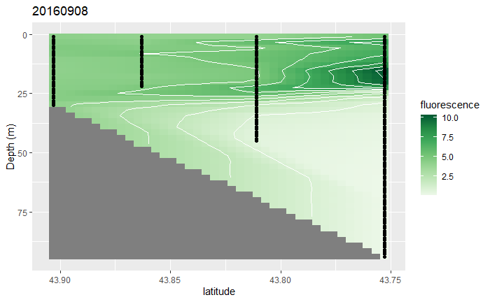

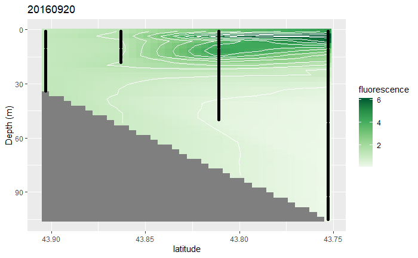

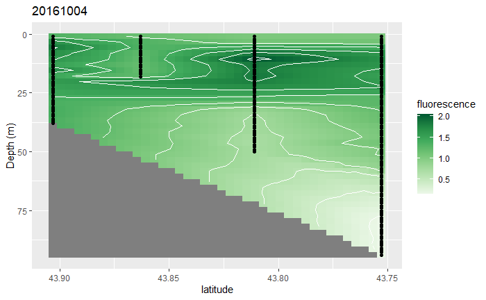

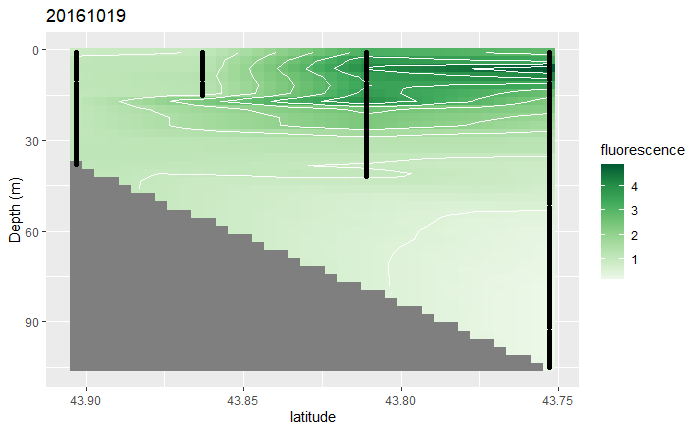

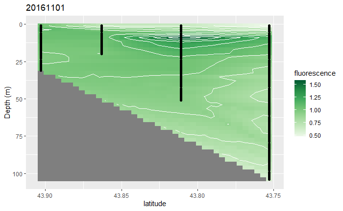

```r
data2016 <- fieldData %>% filter(year == 2016)
alldates <- unique(data2016$date)

for (dd in alldates){
  print(cruiseInterpolationPlot(fieldData,'fluorescence_mg_m3',dd,'fluorescence'))
}
```

A potential problem with the above is each plot has been made with different axis and color bar limits. This makes it hard to directly compare the data for each cruise. One way around that is to include x, y and color bar limits as input arguments to the function.

**Note: depending on your situation, you could “hard-code” the limits into the function itself if you know you’re never going to want to change them.**

## Challenge F

Adapt the `cruiseInterpolationPlot` function such that the x, y and color bar limits are determined from input arguments and re-plot all the fluorescence data for each cruise in 2016. (Hint: use the `xlim` and `ylim` functions with `ggplot` and include the `limits` argument in the `scale_fill_distiller` function.)